The R function `arima()` provides standard errors calculated using observed Fisher information. Suppose a parametric model has a single parameter, $\theta$, and the log-likelihood function when fitting this model to dataset is as follows:

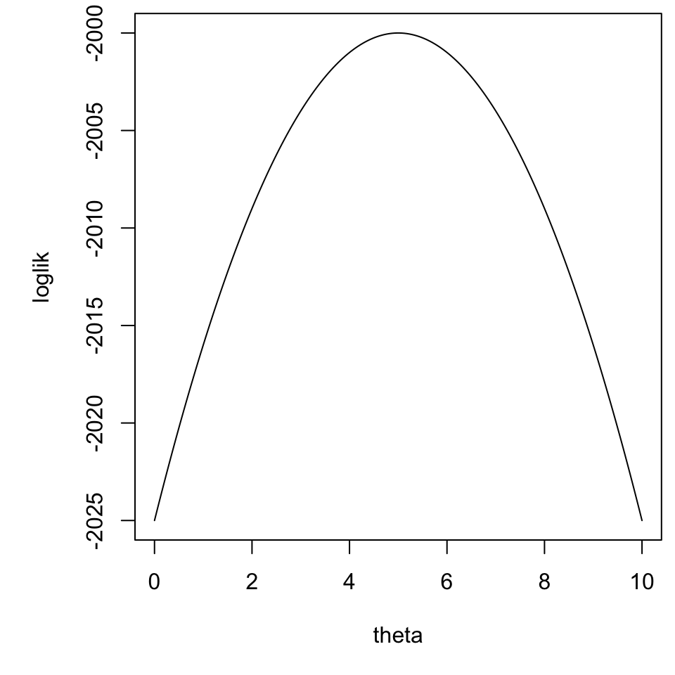

What is the observed Fisher information ($I_{\mathrm obs}$) for $\theta$?

It may be helpful to note that the observed Fisher information is accumulated over the whole dataset, not calculated per observation, so we don’t have to know the number of observations, $N$.

Also, for time series models, we do not usually model observations as independent. Thus, the log-likelihood is not the sum of the log-likelihood for each observation. Its calculation involves consideration of the dependence, and is usually carried out by a computer program.

For checking your answer, it may help to know that the usual variance estimate for the maximum likelihood estimate, $\theta_{MLE}$, is $\mathrm{Var}(\theta_{MLE}) \approx 1/I_{\mathrm obs}$.

A: $I_{\mathrm obs}=2$

B: $I_{\mathrm obs}=1$

C: $I_{\mathrm obs}=1/2$

D: $I_{\mathrm obs}=1/4$

E: None of the above